# Estimation of Person Trip Rates

Kihong Kim and Liming Wang, Ph.D.

3/23/2015

### Overview

We develop (1) linear regression models and (2) zero inflated negative binomial models to estimate person trip rates.

- Models are specified for each of the following home-based trip purposes.
  - hbw: home-based work trips
  - hbs: home-based shopping trips
  - hbr: home-based recreation trips
  - hbo: home-based non-school other trips
- The dependent variable is the number of linked trips, not place-based trips, at the person level. For example, in the Year 2011 Oregon Travel and Activity Survey, which is a place-based survey, a transit travel is coded with 3 trips, including transit access, in transit, and transit egress. In our study, we use linked trips; that is, we convert the transit travel from 3 trips to 1 trip.
- Two sets of independent variables are considered:
  - sociodemographic characteristics of persons and their households (SD) from 2011 OTAS
  - built environment characteristics of person’s home census block groups (BE) from EPA’s Smart Location Database
  - the SD variables: household size, number of workers, number of students, household income, etc.
  - the BE variables: EPA’s Smart Location Database (Density (D1), Diversity (D2), Design (D3), Transit (D4), and Destination Accessibility (D5)

### Load data from the PostgreSQL database

Two different data sources are considered

- 2011 Oregon Travel Activity Survey
  - activity
  - person
  - household
- EPA’s Smart Location Database
  - downloaded from [Smart Location Mapping](http://www.epa.gov/smartgrowth/smartlocationdatabase.htm) for our study area, and then converted to EPSG 2913 for the Coordinate Reference System
  - for a full description of all variablels, please refer to [its Users’ Guide](http://www.epa.gov/smartgrowth/pdf/sld_userguide.pdf)
  - the household file and the Smart Location Database were spatially joined based on households’ home census block groups, which is hh_sld

```r
library(dplyr)
library(stargazer)
library(pscl) # to call a function for Zero-Inflated Negative Binomial model estimation
setwd("~/tci")
INPUT_DIR <- 'data/'
load(file.path(INPUT_DIR, "OHAS_PDX.RData"))
load(file.path(INPUT_DIR, "sld.RData")) # EPA's Smart Location Database spatially joined with household

activity <- with(activity, activity[order(sampn,perno,plano),])
activity$actNo <- with(activity, ave(plano, sampn,perno, FUN=seq))
activity$maxAct <- with(activity, ave(actNo, sampn,perno, FUN=length))
```

### Create a dependent variable for each home-based trip purpose : number of linked trips per person

- hbw (home-based work); work, not including all other activities at work and work related activities
- hbs (home-based shopping); both routine and special shopping
- hbr (home-based recreation); both outdoor and indoor recreation
- hbo (home-based other); other home-based trips, not including school activities but including all other activities at school

```r
# create a new data set without the Change-of-Mode activities in the middle of the day to use only linked trips
linked <- subset(activity, !(tpurp==7 & actNo!=1 & actNo!=maxAct))
# update actNo and maxAct
linked$actNo <- with(linked, ave(plano, sampn,perno, FUN=seq))
linked$maxAct <- with(linked, ave(actNo, sampn,perno, FUN=length))
# update lastaggact
linked$lastaggact <- c(NA, linked$thisaggact[-length(linked$thisaggact)])
linked$lastaggact[linked$actNo==1] <- NA
# update last_tpurp
linked$last_tpurp <- c(NA, linked$tpurp[-length(linked$tpurp)])
linked$last_tpurp[linked$actNo==1] <- NA
# identity trip purposes
attach(linked)
# hbw
linked$hbw <- 0
linked$hbw[ ((last_tpurp==1|last_tpurp==2)&tpurp==3) | (last_tpurp==3&(tpurp==1|tpurp==2)) ] <- 1
# hbs
linked$hbs <- 0
linked$hbs[ ((last_tpurp==1|last_tpurp==2)&tpurp%in%c(13,14)) | (last_tpurp%in%c(13,14)&(tpurp==1|tpurp==2)) ] <- 1
# hbr
linked$hbr <- 0
linked$hbr[ ((last_tpurp==1|last_tpurp==2)&tpurp%in%c(20,21)) | (last_tpurp%in%c(20,21)&(tpurp==1|tpurp==2)) ] <- 1
# hbo
linked$hbo <- 0
linked$hbo[ ((last_tpurp==1|last_tpurp==2)&(tpurp%in%c(4,6,7,8,9,10,11,12,15,16,17,18,19,22,96,97))) |
              ((last_tpurp%in%c(4,6,7,8,9,10,11,12,15,16,17,18,19,22,96,97))&(tpurp==1|tpurp==2)) ] <- 1
detach(linked)
# calculate the number of linked trips by home-based trip purposes at the person level
linked$perid <- with(linked, sampn*10+perno)
hbw <- linked %>% group_by(perid) %>% summarise(numtrips=sum(hbw))
hbs <- linked %>% group_by(perid) %>% summarise(numtrips=sum(hbs))
hbr <- linked %>% group_by(perid) %>% summarise(numtrips=sum(hbr))
hbo <- linked %>% group_by(perid) %>% summarise(numtrips=sum(hbo))
```

### Add independent variables

```r
# create independent variables
# person
person$perid <- with(person, sampn*10 + perno)
person$female <- with(person, ifelse(gend==2,1,0))
person$female[(person$gend==9)] <- NA
person$age[(person$age==99)] <- NA
person$licensed <- with(person, ifelse(lic==2|is.na(lic),0,1))
person$licensed[(person$lic==9)] <- NA
person$transit <- with(person, ifelse(trans==2|is.na(trans),0,1))
person$transit[(person$trans==8|person$trans==9)] <- NA
person$biker <- with(person, ifelse(pbike==2|is.na(pbike),0,1))
person$biker[(person$pbike==8|person$pbike==9)] <- NA
person$worker <- with(person, ifelse(works==2|is.na(works),0,1))
person$retiree <- with(person, ifelse(wkstat!=1|is.na(wkstat),0,1))
person$homemaker <- with(person, ifelse(wkstat!=3|is.na(wkstat),0,1))
person$student <- with(person, ifelse(wkstat!=6|is.na(wkstat),0,1))
# merge dependent variables with independent variables
hbw <- merge(hbw, person, by="perid"); hbw <- merge(hbw, sld, by="sampn")
hbs <- merge(hbs, person, by="perid"); hbs <- merge(hbs, sld, by="sampn")
hbr <- merge(hbr, person, by="perid"); hbr <- merge(hbr, sld, by="sampn")
hbo <- merge(hbo, person, by="perid"); hbo <- merge(hbo, sld, by="sampn")
```

### Develop linear regression models to estimate person trip rates

```r
# with person characteristics (f1)
f1 <- as.formula(numtrips ~ female+age+licensed+transit+biker+worker+retiree+homemaker+student)
f1.hbw <- lm(f1, data=hbw)
f1.hbs <- lm(f1, data=hbs)
f1.hbr <- lm(f1, data=hbr)
f1.hbo <- lm(f1, data=hbo)
stargazer(f1.hbw, f1.hbs, f1.hbr, f1.hbo, title="Table 1. Linear regression models with person  charactiersitics", type="text")
```

```
##
## Table 1. Linear regression models with person charactiersitics
## =========================================================================
##                                            Dependent variable:
##                                  ----------------------------------------
##                                                  numtrips
##                                     (1)        (2)       (3)       (4)
## -------------------------------------------------------------------------
## female                           -0.065***  0.040***   0.025**  0.129***
##                                   (0.012)    (0.012)   (0.011)   (0.024)
##
## age                              -0.003***  0.004***  -0.002*** -0.002**
##                                   (0.0004)  (0.0004)  (0.0004)   (0.001)
##
## licensed                          0.125***  0.103***  0.074***  0.548***
##                                   (0.023)    (0.023)   (0.022)   (0.048)
##
## transit                           0.211***   -0.001   -0.051*** -0.326***
##                                   (0.020)    (0.020)   (0.018)   (0.041)
##
## biker                              -0.015   0.070***  0.114***  0.235***
##                                   (0.016)    (0.016)   (0.015)   (0.033)
##
## worker                            0.915***  -0.134*** -0.104*** -0.112**
##                                   (0.024)    (0.024)   (0.022)   (0.050)
##
## retiree                           0.090***   -0.022    -0.005    -0.067
##                                   (0.031)    (0.031)   (0.029)   (0.065)
##
## homemaker                          0.042     0.077**  -0.088**  0.700***
##                                   (0.039)    (0.039)   (0.037)   (0.082)
##
## student                           -0.075**  -0.144*** -0.161*** -0.302***
##                                   (0.034)    (0.033)   (0.032)   (0.070)
##
## Constant                          0.062***  0.131***  0.314***  0.802***
##                                   (0.015)    (0.015)   (0.014)   (0.030)
##
## -------------------------------------------------------------------------
## Observations                       14,995    14,995    14,995    14,995
## R2                                 0.301      0.029     0.009     0.039
## Adjusted R2                        0.301      0.029     0.008     0.039
## Residual Std. Error (df = 14985)   0.707      0.707     0.667     1.469
## F Statistic (df = 9; 14985)      717.089*** 50.536*** 15.270*** 67.711***
## =========================================================================
## Note:                                         *p<0.1; **p<0.05; ***p<0.01
```

```r
# add household characteristics (f2)
f2 <- update(f1, ~ . +hhsiz+hhwrk+hhstu+hhveh+hhlic)
f2.hbw <- lm(f2, data=hbw)
f2.hbs <- lm(f2, data=hbs)
f2.hbr <- lm(f2, data=hbr)
f2.hbo <- lm(f2, data=hbo)
stargazer(f2.hbw, f2.hbs, f2.hbr, f2.hbo, title="Table 2. Linear regression models with household charactiersitics", type="text")
```

```
##
## Table 2. Linear regression models with household charactiersitics
## =========================================================================
##                                            Dependent variable:
##                                  ----------------------------------------
##                                                  numtrips
##                                     (1)        (2)       (3)       (4)
## -------------------------------------------------------------------------
## female                           -0.064***  0.036***   0.024**  0.133***
##                                   (0.012)    (0.012)   (0.011)   (0.024)
##
## age                              -0.004***  0.003***  -0.001**  0.004***
##                                   (0.0005)  (0.0005)  (0.0004)   (0.001)
##
## licensed                          0.090***  0.156***  0.087***  0.801***
##                                   (0.026)    (0.026)   (0.024)   (0.053)
##
## transit                           0.209***   -0.019   -0.047**  -0.287***
##                                   (0.020)    (0.020)   (0.019)   (0.041)
##
## biker                              -0.008   0.062***  0.110***  0.218***
##                                   (0.016)    (0.016)   (0.015)   (0.033)
##
## worker                            0.968***  -0.149*** -0.137*** -0.242***
##                                   (0.027)    (0.027)   (0.025)   (0.055)
##
## retiree                           0.084***   -0.029     0.002    -0.064
##                                   (0.031)    (0.031)   (0.030)   (0.064)
##
## homemaker                          0.054      0.062   -0.087**  0.557***
##                                   (0.040)    (0.040)   (0.037)   (0.082)
##
## student                           -0.062*   -0.118*** -0.177*** -0.316***
##                                   (0.034)    (0.034)   (0.032)   (0.070)
##
## hhsiz                              -0.001   0.027***   -0.014   0.117***
##                                   (0.009)    (0.009)   (0.009)   (0.019)
##
## hhwrk                            -0.053***    0.009   0.035***  0.096***
##                                   (0.011)    (0.011)   (0.011)   (0.023)
##
## hhstu                             -0.023**  -0.034*** 0.028***  0.123***
##                                   (0.009)    (0.009)   (0.009)   (0.019)
##
## hhveh                             0.024***  -0.025***  -0.009     0.002
##                                   (0.007)    (0.007)   (0.006)   (0.013)
##
## hhlic                              0.006    -0.042***   0.003   -0.248***
##                                   (0.014)    (0.014)   (0.013)   (0.028)
##
## Constant                          0.147***  0.216***  0.269***  0.307***
##                                   (0.029)    (0.029)   (0.027)   (0.059)
##
## -------------------------------------------------------------------------
## Observations                       14,995    14,995    14,995    14,995
## R2                                 0.304      0.033     0.011     0.062
## Adjusted R2                        0.303      0.032     0.010     0.062
## Residual Std. Error (df = 14980)   0.706      0.706     0.666     1.451
## F Statistic (df = 14; 14980)     466.522*** 36.690*** 11.783*** 71.312***
## =========================================================================
## Note:                                         *p<0.1; **p<0.05; ***p<0.01
```

```r
# add built environment characteristics (f3)
f3 <- update(f2, ~ . +d1a+d1b+d1c5_ret10
                     +d2a_jphh+d2b_e5mix+d2a_ephhm
                     +d3a+d3b)
f3.hbw <- lm(f3, data=hbw)
f3.hbs <- lm(f3, data=hbs)
f3.hbr <- lm(f3, data=hbr)
f3.hbo <- lm(f3, data=hbo)
stargazer(f3.hbw, f3.hbs, f3.hbr, f3.hbo, title="Table 3. Linear regression models with built environment charactiersitics", type="text")
```

```
##
## Table 3. Linear regression models with built environment charactiersitics
## =========================================================================
##                                            Dependent variable:
##                                  ----------------------------------------
##                                                  numtrips
##                                     (1)        (2)       (3)       (4)
## -------------------------------------------------------------------------
## female                           -0.065***  0.036***   0.024**  0.133***
##                                   (0.012)    (0.012)   (0.011)   (0.024)
##
## age                              -0.004***  0.003***   -0.001*  0.004***
##                                   (0.0005)  (0.0005)  (0.0004)   (0.001)
##
## licensed                          0.089***  0.157***  0.088***  0.803***
##                                   (0.026)    (0.026)   (0.024)   (0.053)
##
## transit                           0.207***   -0.026   -0.054*** -0.303***
##                                   (0.020)    (0.020)   (0.019)   (0.041)
##
## biker                              -0.016   0.045***  0.095***  0.185***
##                                   (0.016)    (0.016)   (0.015)   (0.033)
##
## worker                            0.970***  -0.147*** -0.135*** -0.236***
##                                   (0.027)    (0.027)   (0.025)   (0.055)
##
## retiree                           0.086***   -0.030    -0.0002   -0.065
##                                   (0.031)    (0.031)   (0.030)   (0.064)
##
## homemaker                          0.057     0.067*   -0.082**  0.568***
##                                   (0.040)    (0.040)   (0.037)   (0.082)
##
## student                           -0.060*   -0.116*** -0.176*** -0.311***
##                                   (0.034)    (0.034)   (0.032)   (0.069)
##
## hhsiz                              -0.003   0.031***   -0.009   0.126***
##                                   (0.009)    (0.009)   (0.009)   (0.019)
##
## hhwrk                            -0.055***    0.006   0.031***  0.088***
##                                   (0.011)    (0.011)   (0.011)   (0.023)
```

[output cut: 30 more lines]

```
##
## d3b                                0.0001    0.0003    0.00001   -0.0002
##                                   (0.0002)  (0.0002)  (0.0002)  (0.0004)
##
## Constant                          0.125***  0.110***  0.163***    0.077
##                                   (0.039)    (0.039)   (0.037)   (0.080)
##
## -------------------------------------------------------------------------
## Observations                       14,988    14,988    14,988    14,988
## R2                                 0.305      0.036     0.014     0.065
## Adjusted R2                        0.304      0.035     0.012     0.064
## Residual Std. Error (df = 14965)   0.706      0.705     0.665     1.450
## F Statistic (df = 22; 14965)     297.977*** 25.673*** 9.557***  47.297***
## =========================================================================
## Note:                                         *p<0.1; **p<0.05; ***p<0.01
```

### Develop zero-inflated negative binomial (zinb) models

Zero-inflated negative binomial models are useful for a count variable with many zeros, in which the many zeros are generated by a separate process from the count values and the many zeros can be modeled independently.

```r
# hbw
zinb.hbw <- zeroinfl(numtrips ~ female+age+licensed+transit+biker
                     +hhsiz+hhwrk+hhstu+hhveh
                     +d1a+d1b+d1c5_ret10+d2a_jphh+d2b_e5mix+d2a_ephhm+d3a+d3b | 1,
                     data=hbw, dist="negbin",EM=TRUE)
# hbs
zinb.hbs <- zeroinfl(numtrips ~ female+age+licensed+transit+biker+retiree+homemaker+student
                     +hhsiz+hhwrk+hhstu+hhveh
                     +d1a+d1b+d1c5_ret10+d2a_jphh+d2b_e5mix+d2a_ephhm+d3a+d3b | worker,
                     data=hbs, dist="negbin",EM=TRUE)
# hbr
zinb.hbr <- zeroinfl(numtrips ~ female+age+licensed+transit+biker+retiree+homemaker+student
                     +hhsiz+hhwrk+hhstu+hhveh
                     +d1a+d1b+d1c5_ret10+d2a_jphh+d2b_e5mix+d2a_ephhm+d3a+d3b | worker,
                     data=hbr, dist="negbin",EM=TRUE)
# hbo
zinb.hbo <- zeroinfl(numtrips ~ female+age+licensed+transit+biker+retiree+homemaker+student
                     +hhsiz+hhwrk+hhstu+hhveh
                     +d1a+d1b+d1c5_ret10+d2a_jphh+d2b_e5mix+d2a_ephhm+d3a+d3b | worker,
                     data=hbo, dist="negbin",EM=TRUE)
stargazer(zinb.hbw,zinb.hbs,zinb.hbr,zinb.hbo, type="text", title="Table 4. Zero-Inflated Negative Binomial Models")
```

```
##
## Table 4. Zero-Inflated Negative Binomial Models
## =============================================================
##                             Dependent variable:
##                ----------------------------------------------
##                                   numtrips
##                    (1)         (2)        (3)         (4)
## -------------------------------------------------------------
## female          -0.155***    0.073**     0.026     0.078***
##                  (0.025)     (0.034)    (0.040)     (0.020)
##
## age             -0.004***   0.009***   -0.005***   0.003***
##                  (0.001)     (0.001)    (0.002)     (0.001)
##
## licensed        2.303***    0.273***    0.201**    0.434***
##                  (0.074)     (0.065)    (0.079)     (0.038)
##
## transit         0.349***     -0.051     -0.135*    -0.284***
##                  (0.033)     (0.058)    (0.077)     (0.036)
##
## biker            0.058*     0.135***    0.153***   0.113***
##                  (0.030)     (0.044)    (0.051)     (0.025)
##
## retiree                       0.010     0.239***     0.012
##                              (0.061)    (0.081)     (0.039)
##
## homemaker                   0.242***     -0.064    0.332***
##                              (0.082)    (0.122)     (0.046)
##
## student                     -0.360***  -0.432***   -0.290***
##                              (0.122)    (0.128)     (0.061)
##
## hhsiz           -0.225***   0.099***     0.001     0.069***
##                  (0.020)     (0.025)    (0.031)     (0.015)
##
## hhwrk           0.488***    -0.102***    0.038     -0.040**
##                  (0.019)     (0.027)    (0.033)     (0.016)
##
## hhstu           0.080***    -0.121***    0.060*    0.100***
##                  (0.021)     (0.027)    (0.031)     (0.015)
```

[output cut: 21 more lines]

```
##
## d3a              -0.003       0.006      0.010*    0.010***
##                  (0.004)     (0.005)    (0.006)     (0.003)
##
## d3b             -0.00002     0.0004     0.00001     -0.0003
##                 (0.0004)     (0.001)    (0.001)    (0.0003)
##
## Constant        -2.344***   -1.062***   -0.265*    -0.380***
##                  (0.103)     (0.118)    (0.139)     (0.068)
##
## -------------------------------------------------------------
## Observations     14,988      14,988      14,988     14,988
## Log Likelihood -12,764.680 -10,804.790 -8,817.525 -21,533.070
## =============================================================
## Note:                             *p<0.1; **p<0.05; ***p<0.01
```

### Predict person trip rates from random sample (n=1,000)

```r
### create a new data set
set.seed(1234)
randomSample <- linked %>% group_by(perid)  %>% tally %>% sample_n(1000)
newPersons <- left_join(randomSample, person, by="perid") %>%
  left_join(sld, by="sampn") %>% arrange(perid)
### predict the number of trips for each person by trip purpose
# based on linear regression models (lm)
numHBW.lm <- predict(f3.hbw, newdata=newPersons)
numHBS.lm <- predict(f3.hbs, newdata=newPersons)
numHBR.lm <- predict(f3.hbr, newdata=newPersons)
numHBO.lm <- predict(f3.hbo, newdata=newPersons)
summary(numHBW.lm)
```

```
##     Min.  1st Qu.   Median     Mean  3rd Qu.     Max.     NA's
## -0.30100  0.01686  0.82300  0.53610  0.91950  1.32000       14
```

```r
summary(numHBS.lm)
```

```
##     Min.  1st Qu.   Median     Mean  3rd Qu.     Max.     NA's
## -0.07802  0.24550  0.33290  0.33830  0.42800  0.75750       14
```

```r
summary(numHBR.lm)
```

```
##     Min.  1st Qu.   Median     Mean  3rd Qu.     Max.     NA's
## 0.006392 0.203600 0.261700 0.262500 0.317800 0.550000       14
```

```r
summary(numHBO.lm)
```

```
##    Min. 1st Qu.  Median    Mean 3rd Qu.    Max.    NA's
## 0.02365 0.91620 1.11800 1.14100 1.32500 3.13900      14
```

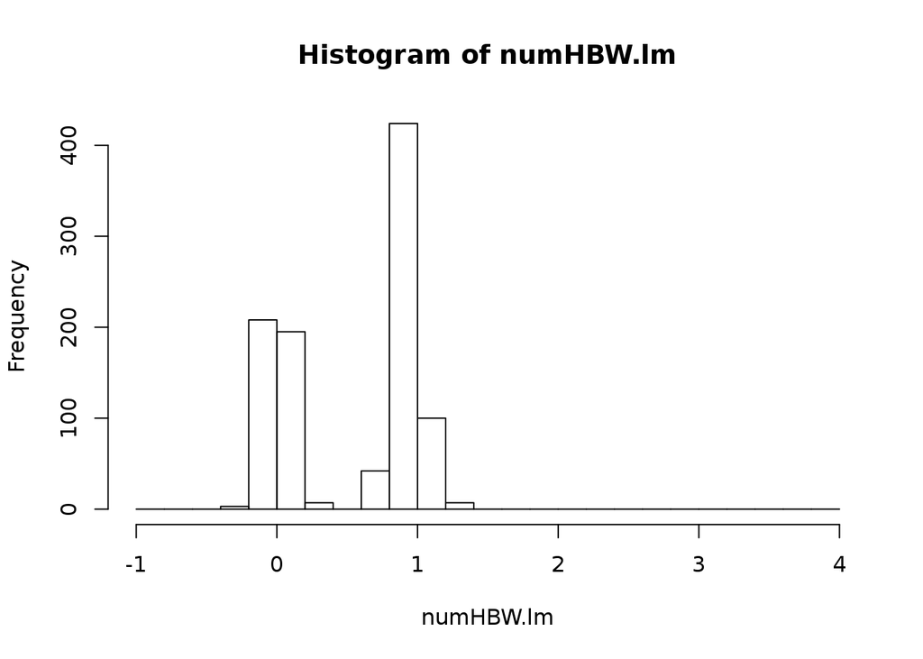

```r
bins=seq(-1,4, by=0.2)
hist(numHBW.lm, breaks=bins)
```

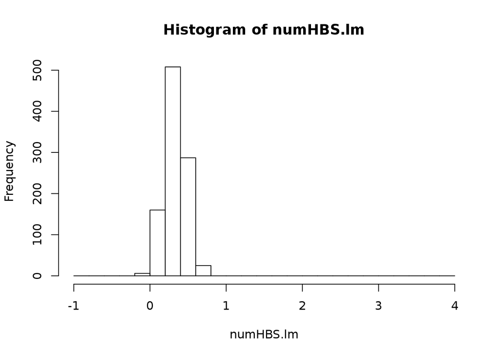

```r
hist(numHBS.lm, breaks=bins)
```

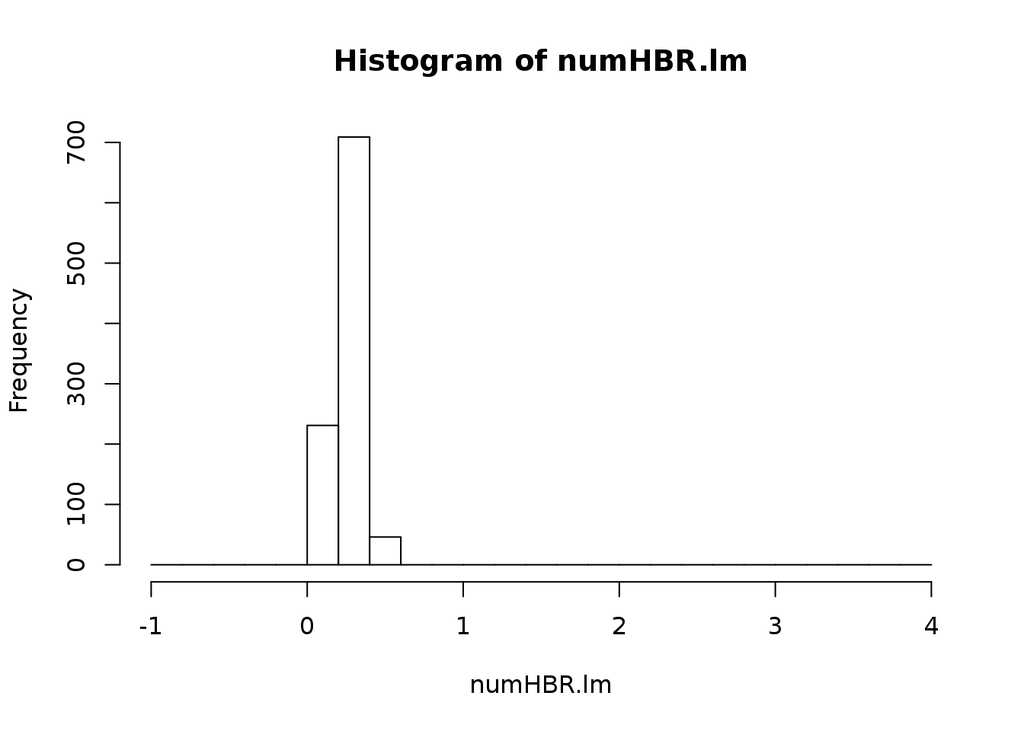

```r
hist(numHBR.lm, breaks=bins)
```

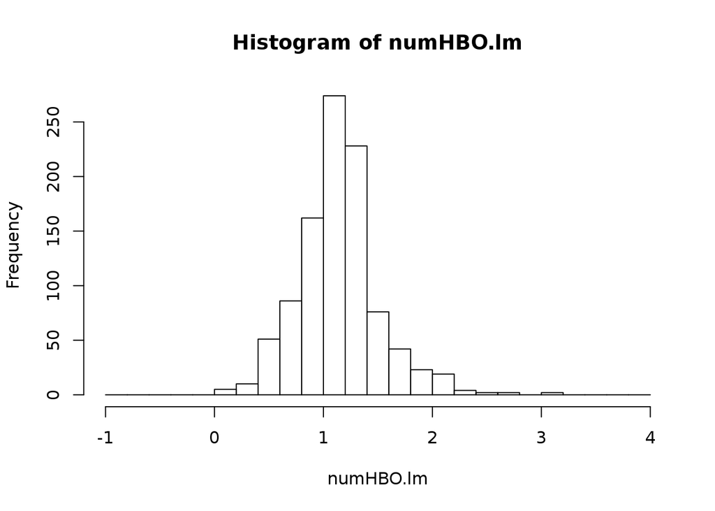

```r
hist(numHBO.lm, breaks=bins)
```

```r
# based on zero-inflated negative binomial models (zinb)
numHBW.zinb <- predict(zinb.hbw, newdata=newPersons)
numHBS.zinb <- predict(zinb.hbs, newdata=newPersons)
numHBR.zinb <- predict(zinb.hbr, newdata=newPersons)
numHBO.zinb <- predict(zinb.hbo, newdata=newPersons)
summary(numHBW.zinb)
```

```
##    Min. 1st Qu.  Median    Mean 3rd Qu.    Max.    NA's
## 0.02138 0.24300 0.55340 0.53310 0.77330 2.31400      14
```

```r
summary(numHBS.zinb)
```

```
##    Min. 1st Qu.  Median    Mean 3rd Qu.    Max.    NA's
## 0.07667 0.24470 0.32780 0.33380 0.40710 0.74940      14
```

```r
summary(numHBR.zinb)
```

```
##    Min. 1st Qu.  Median    Mean 3rd Qu.    Max.    NA's
##  0.1404  0.2125  0.2519  0.2562  0.2933  0.4790      14
```

```r
summary(numHBO.zinb)
```

```
##    Min. 1st Qu.  Median    Mean 3rd Qu.    Max.    NA's
##  0.4580  0.9275  1.1130  1.1390  1.2650  3.9920      14
```

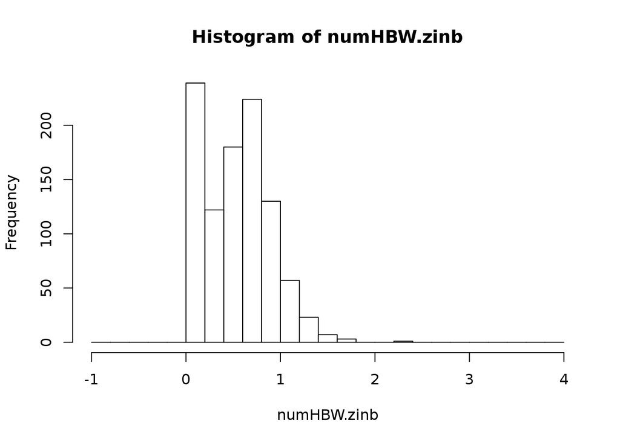

```r
hist(numHBW.zinb, breaks=bins)
```

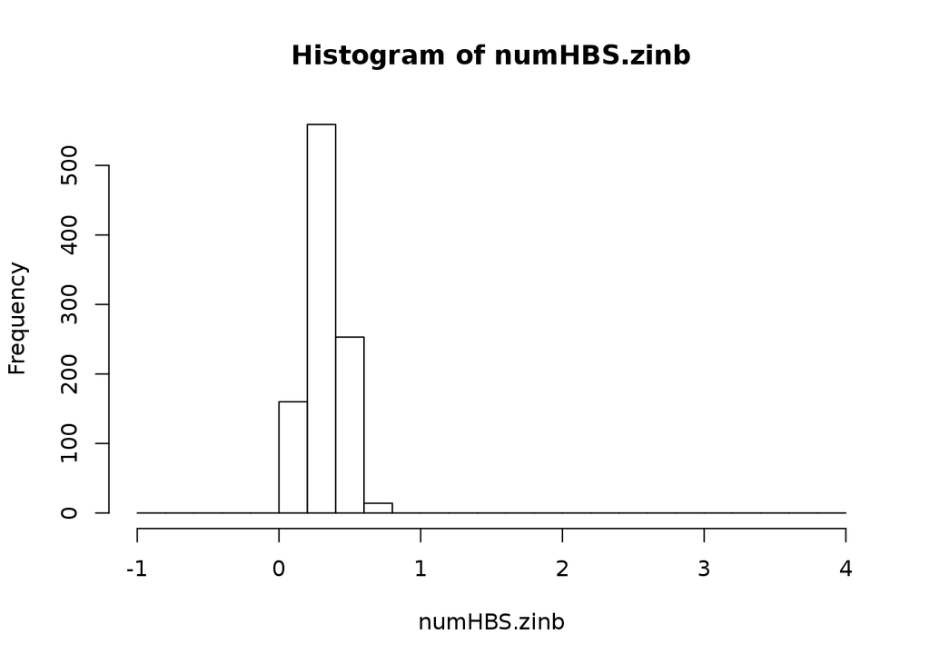

```r
hist(numHBS.zinb, breaks=bins)
```

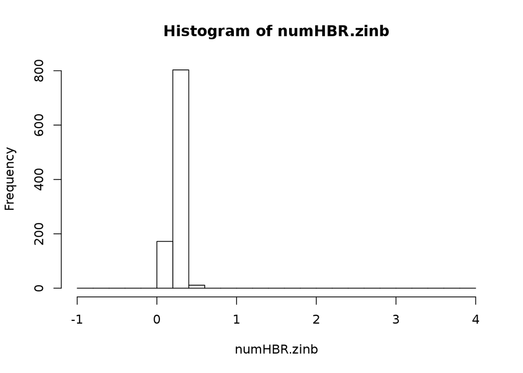

```r
hist(numHBR.zinb, breaks=bins)
```

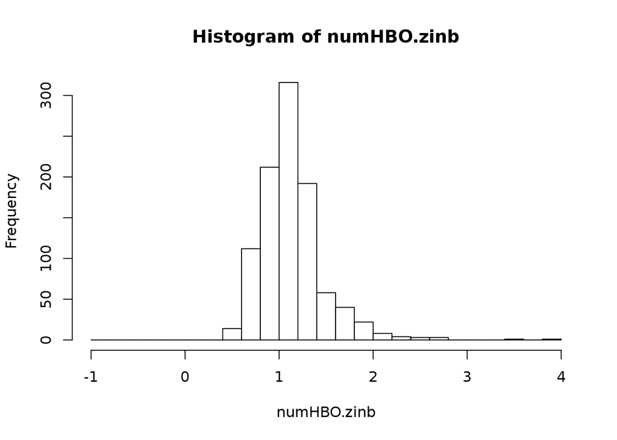

```r
hist(numHBO.zinb, breaks=bins)
```